# MarketingCampaign_MF

## Understanding Outliers using Boxplots

```python
# Numerical columns with variance and distribution
numerical_features = list(marketing_data.select_dtypes(include=['float32', 'int16']).columns)
binary_features = ['AcceptedCmp3', 'AcceptedCmp4', 'AcceptedCmp5', 'AcceptedCmp1', 'AcceptedCmp2', 'Response', 'Complain']

# Numerical_features excluding binary for checking distributions and outliers
numerical_features_exclBinary = [x for x in numerical_features if x not in binary_features]
numerical_features_exclBinary
```

```
['Income',
 'Recency',
 'MntWines',
 'MntFruits',
 'MntMeatProducts',
 'MntFishProducts',
 'MntSweetProducts',
 'MntGoldProds',
 'NumDealsPurchases',
 'NumWebPurchases',
 'NumCatalogPurchases',
 'NumStorePurchases',
 'NumWebVisitsMonth',
 'Total_Children',
 'Age',
 'Total_Spending',
 'Total_Purchases']
```

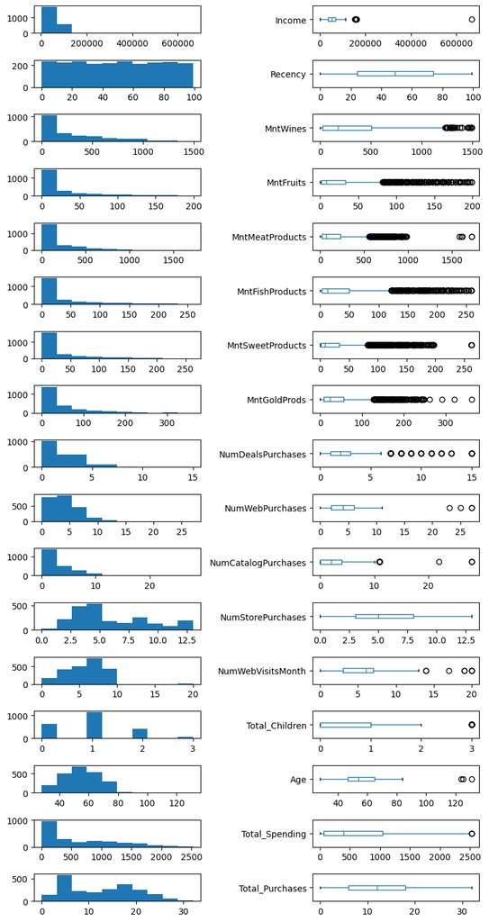

```python
# Generate histograms and boxplots

fig, axes = plt.subplots(nrows=len(numerical_features_exclBinary), ncols=2, figsize=(8,15))
for i, col in enumerate(numerical_features_exclBinary):
    marketing_data[col].hist(ax=axes[i, 0], grid=False)
    marketing_data.boxplot(column=col, ax=axes[i, 1], grid=False, vert=False)

plt.tight_layout()
plt.show()
```

We see that there are a number of outliers that are causing skewness (right tail) across most of the features. Hence we need to perform Outlier treatment.

## Outlier Treatment

```python
from feature_engine.outliers import Winsorizer

capper = Winsorizer(capping_method='iqr', tail='both', fold=1.5, variables=numerical_features_exclBinary)
marketing_data_no_outliers = capper.fit_transform(marketing_data)
```

Outlier treatment completed

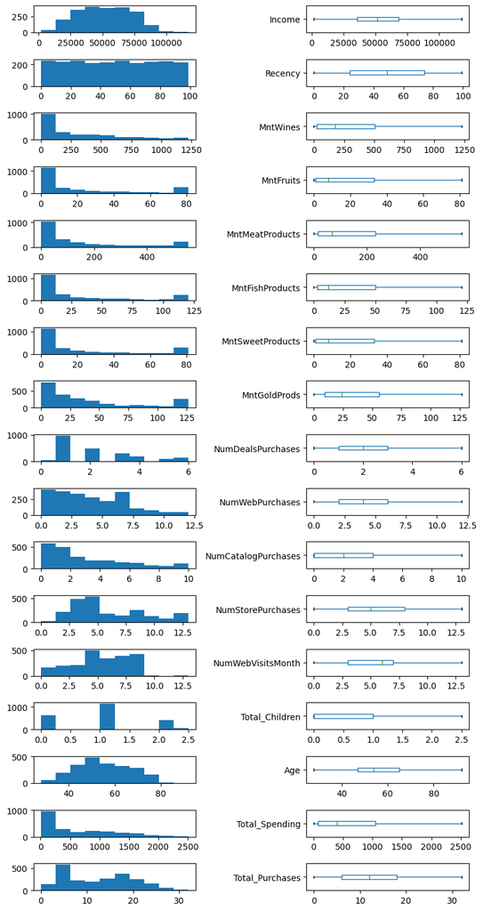

```python
# Generate histograms and boxplots after Outlier treatment

fig, axes = plt.subplots(nrows=len(numerical_features_exclBinary), ncols=2, figsize=(8,15))
for i, col in enumerate(numerical_features_exclBinary):
    marketing_data_no_outliers[col].hist(ax=axes[i, 0], grid=False)
    marketing_data_no_outliers.boxplot(column=col, ax=axes[i, 1], grid=False, vert=False)

plt.tight_layout()
plt.show()
```

Outliers have been removed successfully.

## Understanding distributions using Pairplot

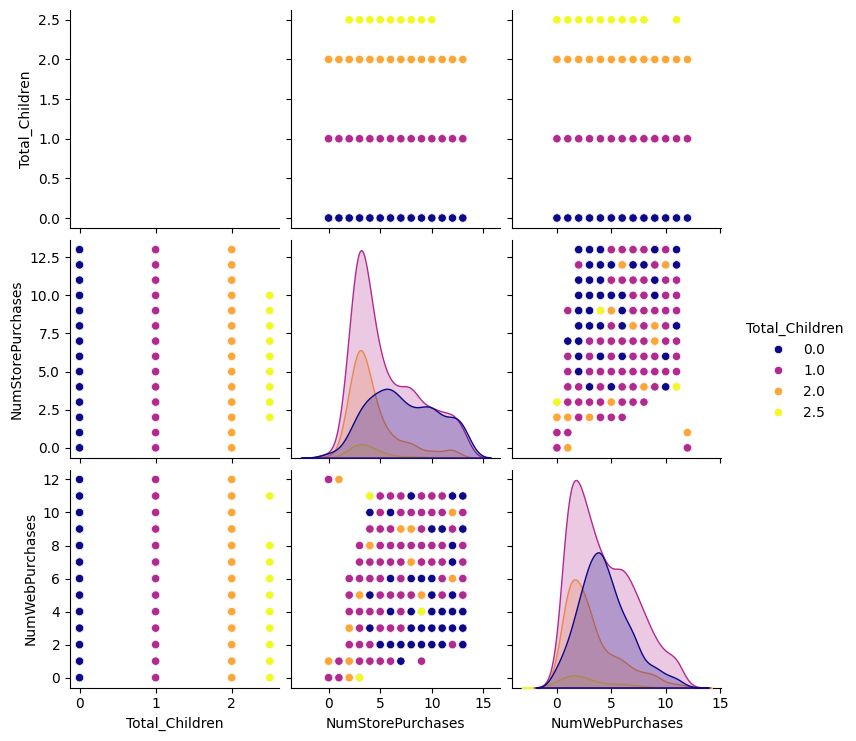

```python
# Distribution of Customers with kids vs. Store purchases vs. Online purchases

sns.pairplot(vars=["Total_Children", "NumStorePurchases","NumWebPurchases"], data=marketing_data_no_outliers, kind="scatter", hue="Total_Children", palette='plasma')
plt.show()
```

From the above graphs, we can infer that number of purchases decreases with increase in number of children.

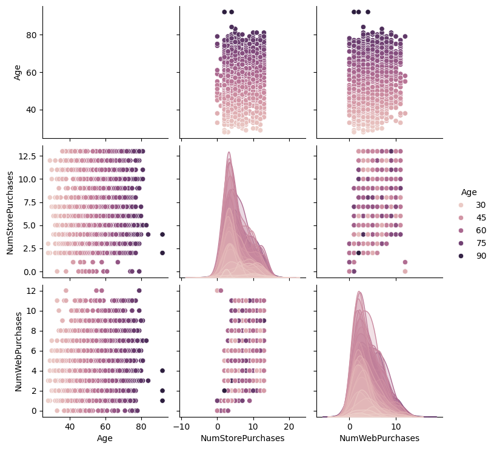

```python
# Distribution of Customers Age vs. Store purchases vs. Online purchases

sns.pairplot(vars=["Age", "NumStorePurchases","NumWebPurchases"], data=marketing_data_no_outliers, kind="scatter", hue="Age")
plt.show()
```

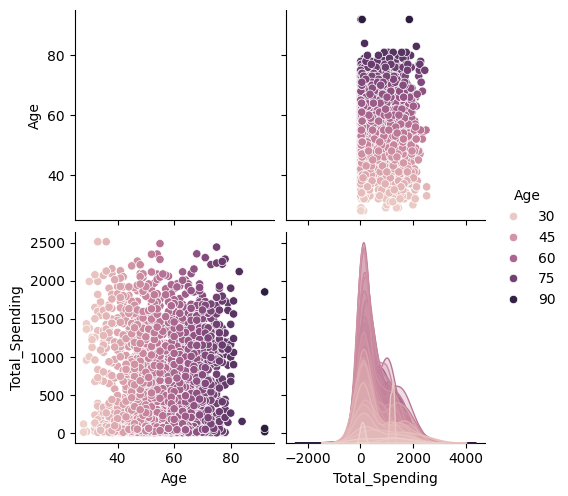

```python
# Distribution of Customers Age vs. Total_Spending

sns.pairplot(vars=["Age", "Total_Spending"], data=marketing_data_no_outliers, kind="scatter", hue="Age")
plt.show()
```

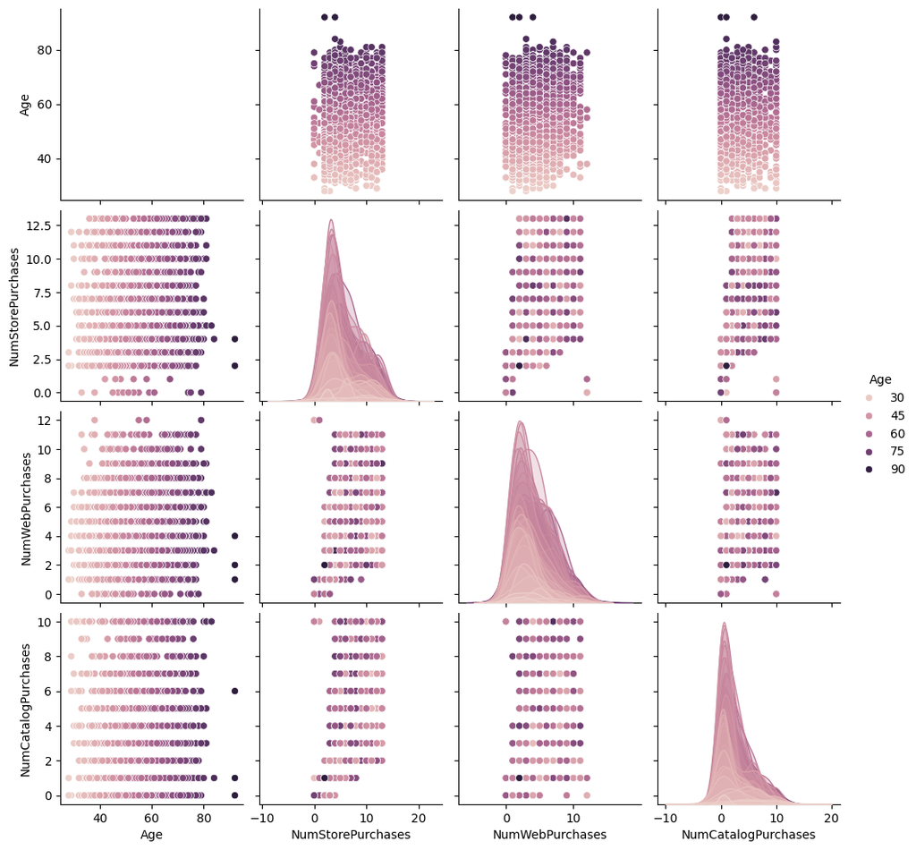

```python
# Distribution of Customers Age vs. Store sales vs. Other distribution channels

sns.pairplot(vars=['Age',"NumStorePurchases", "NumWebPurchases",'NumCatalogPurchases'], data=marketing_data_no_outliers, kind="scatter", hue='Age')
plt.show()
```

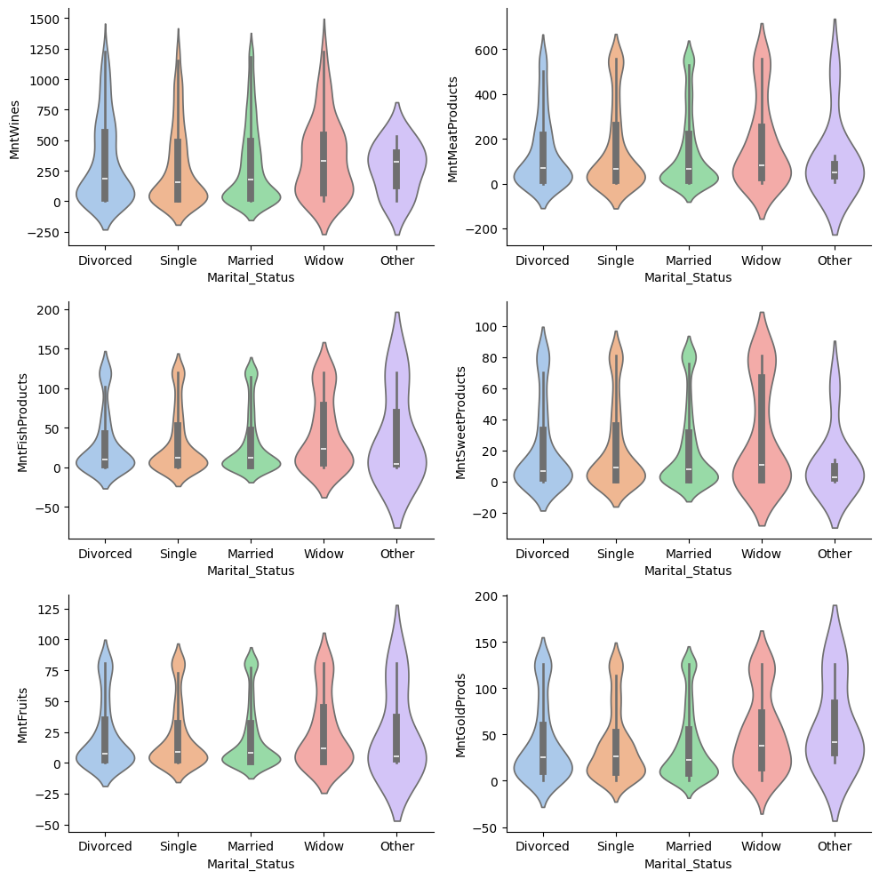

```python
# Distribution of Customers Marital status vs. Amount spent on Wines, Fruits & Meats

list1=['MntWines',"MntMeatProducts"]
list2=['MntFishProducts','MntSweetProducts']
list3=["MntFruits",'MntGoldProds']

fig, axes = plt.subplots(nrows=3, ncols=2, figsize=(10,10))
for i, col in enumerate(list1):
    sns.violinplot(data=marketing_data_no_outliers, x='Marital_Status', y=list1[i],ax=axes[0,i],hue='Marital_Status', palette='pastel')
    sns.violinplot(data=marketing_data_no_outliers, x='Marital_Status', y=list2[i],ax=axes[1,i],hue='Marital_Status', palette='pastel')
    sns.violinplot(data=marketing_data_no_outliers, x='Marital_Status', y=list3[i],ax=axes[2,i],hue='Marital_Status', palette='pastel')
    sns.despine()

plt.tight_layout()
plt.show()
```

Inferences:

- Widows spend more on Wines
- Other category (YOLO, Aline, Absurd) spends more on Wine and Gold products

We can have offers catering to these specific customer demographic.

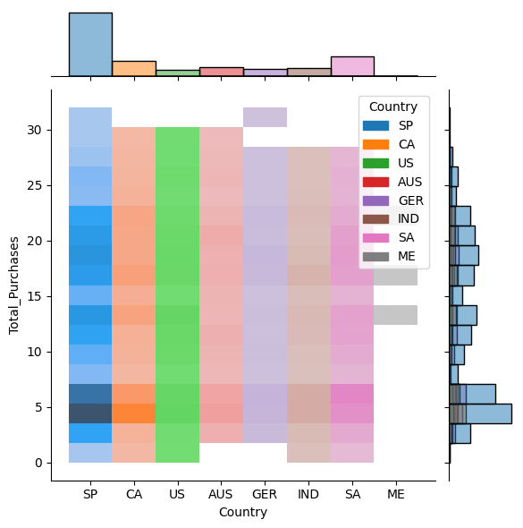

```python
# Distribution of Total_Puchases vs. Country

sns.jointplot(x='Country',y="Total_Purchases", data=marketing_data_no_outliers, kind="hist", hue='Country')
plt.show()
```

## Encoding

```python
# Check statistics for categorical columns

marketing_data_no_outliers.describe(include='O')
```

|  | Education | Marital_Status | Country |
| --- | --- | --- | --- |
| count | 2240 | 2240 | 2240 |
| unique | 5 | 5 | 8 |
| top | Graduation | Married | SP |
| freq | 1127 | 1444 | 1095 |

```python
# Value count of each category

for col in marketing_data_no_outliers.select_dtypes(include='object').columns:
    print(marketing_data_no_outliers[col].value_counts(),'\n')
```

```
Education
Graduation    1127
PhD            486
Master         370
2n Cycle       203
Basic           54
Name: count, dtype: int64

Marital_Status
Married     1444
Single       480
Divorced     232
Widow         77
Other          7
Name: count, dtype: int64

Country
SP     1095
SA      337
CA      268
AUS     160
IND     148
GER     120
US      109
ME        3
Name: count, dtype: int64
```

```python
# Rare Label Encoder

from feature_engine.encoding import RareLabelEncoder

rare_encoder = RareLabelEncoder()
marketing_data_encoded = rare_encoder.fit_transform(marketing_data_no_outliers)
```

- Rare label encoder replaces rare category with 'Rare'
- tolerance 0.05 => below which it marks as Rare

```python
# Ordinal Encoder

from feature_engine.encoding import OrdinalEncoder

ord_encoder = OrdinalEncoder(encoding_method='arbitrary')
marketing_data_encoded = ord_encoder.fit_transform(marketing_data_encoded)
```

Ordinal encoder replaces categories with digits:

1. Arbitrary
- Arbitrarily assigns 0, 1, 2..
1. Ordered
- computes avg. of each category
- sort in ascending order
- assigns 0, 1, 2..

```python
marketing_data_encoded.head()
```

|  | Education | Marital_Status | Income | Recency | MntWines | MntFruits | MntMeatProducts | MntFishProducts | MntSweetProducts | MntGoldProds | ... | AcceptedCmp5 | AcceptedCmp1 | AcceptedCmp2 | Response | Complain | Country | Total_Children | Age | Total_Spending | Total_Purchases |
| --- | --- | --- | --- | --- | --- | --- | --- | --- | --- | --- | --- | --- | --- | --- | --- | --- | --- | --- | --- | --- | --- |
| 0 | 0 | 0 | 84835.0 | 0 | 189 | 81 | 379 | 111.0 | 81 | 126.5 | ... | 0 | 0 | 0 | 1 | 0 | 0 | 0.0 | 54 | 1190.0 | 14 |
| 1 | 0 | 1 | 57091.0 | 0 | 464 | 5 | 64 | 7.0 | 0 | 37.0 | ... | 0 | 0 | 1 | 1 | 0 | 1 | 0.0 | 63 | 577.0 | 17 |
| 2 | 0 | 2 | 67267.0 | 0 | 134 | 11 | 59 | 15.0 | 2 | 30.0 | ... | 0 | 0 | 0 | 0 | 0 | 2 | 1.0 | 66 | 251.0 | 10 |
| 3 | 0 | 2 | 32474.0 | 0 | 10 | 0 | 1 | 0.0 | 0 | 0.0 | ... | 0 | 0 | 0 | 0 | 0 | 3 | 2.0 | 57 | 11.0 | 3 |
| 4 | 0 | 1 | 21474.0 | 0 | 6 | 16 | 24 | 11.0 | 0 | 34.0 | ... | 0 | 0 | 0 | 1 | 0 | 0 | 1.0 | 35 | 91.0 | 6 |

5 rows × 27 columns

## Correlation

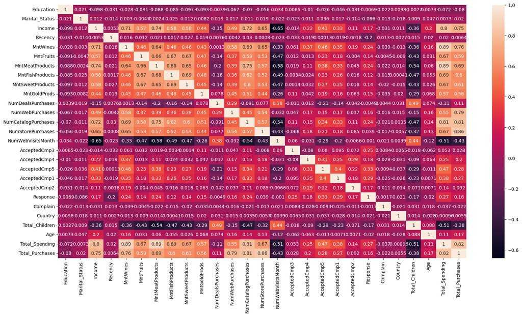

```python
plt.figure(figsize=(20, 10))
sns.heatmap(marketing_data_encoded.corr(), annot=True)
plt.show()
```

- Negative correlation between Total Childrean and Total Spending
- Postitive correlation between Total Spending and Amount spent on Wines & Meat

## Hypothesis Testing

Before beginning with Hypothesis testing, we need to run an **`Anderson-Darling`** test in order to check for normality (Gaussian distribution) of our features. This will help us determine:

- Are our features normally distributed
- If not, do they need variance stabilizing transformations to make them normally distributed
- Which test should be used for Hypothesis testing (T-test, Anova, Chi-Square)

```
 Column:  Income  - Statistic: 8.416
```

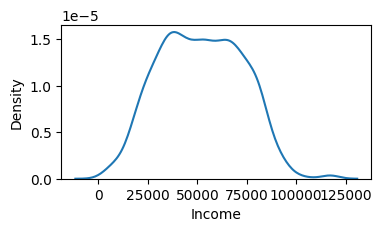

```
Income - 15.0%: Not Gaussian (reject H0)
Income - 10.0%: Not Gaussian (reject H0)
Income - 5.0%: Not Gaussian (reject H0)
Income - 2.5%: Not Gaussian (reject H0)
Income - 1.0%: Not Gaussian (reject H0)


 Column:  Total_Children  - Statistic: 176.858
```

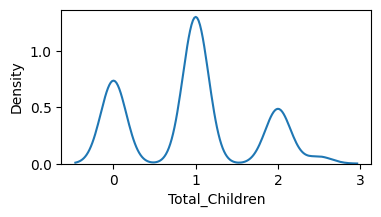

```
Total_Children - 15.0%: Not Gaussian (reject H0)
Total_Children - 10.0%: Not Gaussian (reject H0)
Total_Children - 5.0%: Not Gaussian (reject H0)
Total_Children - 2.5%: Not Gaussian (reject H0)
Total_Children - 1.0%: Not Gaussian (reject H0)


 Column:  Age  - Statistic: 9.844
```

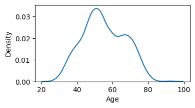

```
Age - 15.0%: Not Gaussian (reject H0)
Age - 10.0%: Not Gaussian (reject H0)
Age - 5.0%: Not Gaussian (reject H0)
Age - 2.5%: Not Gaussian (reject H0)
Age - 1.0%: Not Gaussian (reject H0)


 Column:  Total_Spending  - Statistic: 107.261
```

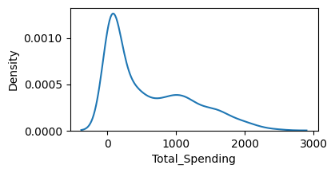

```
Total_Spending - 15.0%: Not Gaussian (reject H0)
Total_Spending - 10.0%: Not Gaussian (reject H0)
Total_Spending - 5.0%: Not Gaussian (reject H0)
Total_Spending - 2.5%: Not Gaussian (reject H0)
Total_Spending - 1.0%: Not Gaussian (reject H0)
```

```python
for column in ['Income', 'Total_Children','Age','Total_Spending']:
    result = stats.anderson(marketing_data_encoded[column], dist='norm')
    print('\n\n',f'Column: \033[1m {column} \033[0m - Statistic: {result.statistic:.3f}')
    plt.figure(figsize=(4,2))
    sns.kdeplot(marketing_data_encoded[column])
    plt.show()

    # Interpreting the result
    for i in range(len(result.critical_values)):
        sl, cv = result.significance_level[i], result.critical_values[i]
        if result.statistic < cv:
            print(f'{column} - {sl}%: Gaussian (fail to reject H0)')
        else:
            print(f'{column} - {sl}%: Not Gaussian (reject H0)')
```

For `'Income'`, `'Total_Children'`,`'Age'`,`'Total_Spending'` the test statistic is higher that critical values at all significance levels. Hence, we reject the Null hypothesis that the feature is Normally distributed.

- These columns are **Not Normally Distributed**

```
 Column:  NumDealsPurchases  - Statistic: 158.205
```

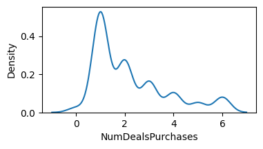

```
NumDealsPurchases - 15.0%: Not Gaussian (reject H0)
NumDealsPurchases - 10.0%: Not Gaussian (reject H0)
NumDealsPurchases - 5.0%: Not Gaussian (reject H0)
NumDealsPurchases - 2.5%: Not Gaussian (reject H0)
NumDealsPurchases - 1.0%: Not Gaussian (reject H0)


 Column:  NumWebPurchases  - Statistic: 48.503
```

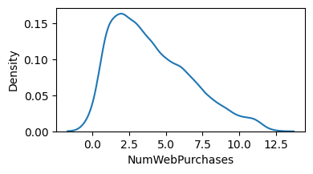

```
NumWebPurchases - 15.0%: Not Gaussian (reject H0)
NumWebPurchases - 10.0%: Not Gaussian (reject H0)
NumWebPurchases - 5.0%: Not Gaussian (reject H0)
NumWebPurchases - 2.5%: Not Gaussian (reject H0)
NumWebPurchases - 1.0%: Not Gaussian (reject H0)


 Column:  NumCatalogPurchases  - Statistic: 111.460
```

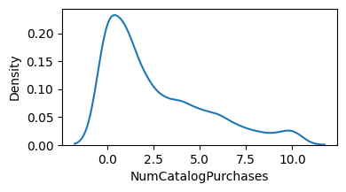

```
NumCatalogPurchases - 15.0%: Not Gaussian (reject H0)
NumCatalogPurchases - 10.0%: Not Gaussian (reject H0)
NumCatalogPurchases - 5.0%: Not Gaussian (reject H0)
NumCatalogPurchases - 2.5%: Not Gaussian (reject H0)
NumCatalogPurchases - 1.0%: Not Gaussian (reject H0)


 Column:  NumStorePurchases  - Statistic: 78.277
```

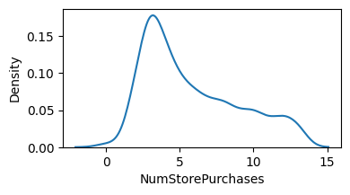

```
NumStorePurchases - 15.0%: Not Gaussian (reject H0)
NumStorePurchases - 10.0%: Not Gaussian (reject H0)
NumStorePurchases - 5.0%: Not Gaussian (reject H0)
NumStorePurchases - 2.5%: Not Gaussian (reject H0)
NumStorePurchases - 1.0%: Not Gaussian (reject H0)
```

```python
for column in ['NumDealsPurchases','NumWebPurchases', 'NumCatalogPurchases','NumStorePurchases']:
    result = stats.anderson(marketing_data_encoded[column], dist='norm')
    print('\n\n',f'Column: \033[1m {column} \033[0m - Statistic: {result.statistic:.3f}')
    plt.figure(figsize=(4,2))
    sns.kdeplot(marketing_data_encoded[column])
    plt.show()

    # Interpreting the result
    for i in range(len(result.critical_values)):
        sl, cv = result.significance_level[i], result.critical_values[i]
        if result.statistic < cv:
            print(f'{column} - {sl}%: Gaussian (fail to reject H0)')
        else:
            print(f'{column} - {sl}%: Not Gaussian (reject H0)')
```

For `'NumDealsPurchases'`, `'NumWebPurchases'`,`'NumCatalogPurchases'`,`'NumStorePurchases'` the test statistic is higher that critical values at all significance levels. Hence, we reject the Null hypothesis that the feature is Normally distributed.

- These columns are **Not Normally Distributed**

```
 Column:  NumWebVisitsMonth  - Statistic: 42.284
```

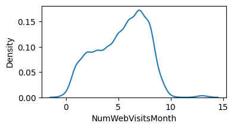

```
NumWebVisitsMonth - 15.0%: Not Gaussian (reject H0)
NumWebVisitsMonth - 10.0%: Not Gaussian (reject H0)
NumWebVisitsMonth - 5.0%: Not Gaussian (reject H0)
NumWebVisitsMonth - 2.5%: Not Gaussian (reject H0)
NumWebVisitsMonth - 1.0%: Not Gaussian (reject H0)


 Column:  Recency  - Statistic: 25.305
```

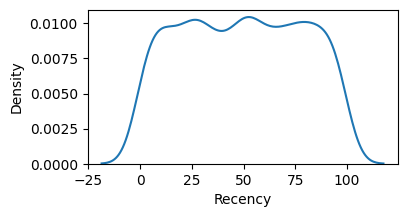

```
Recency - 15.0%: Not Gaussian (reject H0)
Recency - 10.0%: Not Gaussian (reject H0)
Recency - 5.0%: Not Gaussian (reject H0)
Recency - 2.5%: Not Gaussian (reject H0)
Recency - 1.0%: Not Gaussian (reject H0)


 Column:  Total_Purchases  - Statistic: 50.931
```

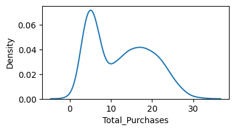

```
Total_Purchases - 15.0%: Not Gaussian (reject H0)
Total_Purchases - 10.0%: Not Gaussian (reject H0)
Total_Purchases - 5.0%: Not Gaussian (reject H0)
Total_Purchases - 2.5%: Not Gaussian (reject H0)
Total_Purchases - 1.0%: Not Gaussian (reject H0)
```

```python
for column in ['NumWebVisitsMonth','Recency','Total_Purchases']:
    result = stats.anderson(marketing_data_encoded[column], dist='norm')
    print('\n\n',f'Column: \033[1m {column} \033[0m - Statistic: {result.statistic:.3f}')
    plt.figure(figsize=(4,2))
    sns.kdeplot(marketing_data_encoded[column])
    plt.show()

    # Interpreting the result
    for i in range(len(result.critical_values)):
        sl, cv = result.significance_level[i], result.critical_values[i]
        if result.statistic < cv:
            print(f'{column} - {sl}%: Gaussian (fail to reject H0)')
        else:
            print(f'{column} - {sl}%: Not Gaussian (reject H0)')
```

For `'NumWebVisitsMonth'`, `'Recency'`,`'Total_Purchases'` the test statistic is higher that critical values at all significance levels. Hence, we reject the Null hypothesis that the feature is Normally distributed.

- These columns are **Not Normally Distributed**

```
 Column:  MntFishProducts  - Statistic: 217.099
```

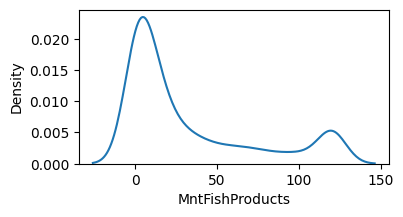

```
MntFishProducts - 15.0%: Not Gaussian (reject H0)
MntFishProducts - 10.0%: Not Gaussian (reject H0)
MntFishProducts - 5.0%: Not Gaussian (reject H0)
MntFishProducts - 2.5%: Not Gaussian (reject H0)
MntFishProducts - 1.0%: Not Gaussian (reject H0)


 Column:  MntSweetProducts  - Statistic: 214.940
```

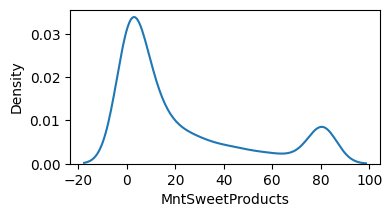

```
MntSweetProducts - 15.0%: Not Gaussian (reject H0)
MntSweetProducts - 10.0%: Not Gaussian (reject H0)
MntSweetProducts - 5.0%: Not Gaussian (reject H0)
MntSweetProducts - 2.5%: Not Gaussian (reject H0)
MntSweetProducts - 1.0%: Not Gaussian (reject H0)


 Column:  MntGoldProds  - Statistic: 143.956
```

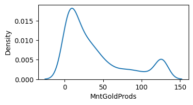

```
MntGoldProds - 15.0%: Not Gaussian (reject H0)
MntGoldProds - 10.0%: Not Gaussian (reject H0)
MntGoldProds - 5.0%: Not Gaussian (reject H0)
MntGoldProds - 2.5%: Not Gaussian (reject H0)
MntGoldProds - 1.0%: Not Gaussian (reject H0)
```

```python
for column in ['MntFishProducts','MntSweetProducts','MntGoldProds']:
    result = stats.anderson(marketing_data_encoded[column], dist='norm')
    print('\n\n',f'Column: \033[1m {column} \033[0m - Statistic: {result.statistic:.3f}')
    plt.figure(figsize=(4,2))
    sns.kdeplot(marketing_data_encoded[column])
    plt.show()

    # Interpreting the result
    for i in range(len(result.critical_values)):
        sl, cv = result.significance_level[i], result.critical_values[i]
        if result.statistic < cv:
            print(f'{column} - {sl}%: Gaussian (fail to reject H0)')
        else:
            print(f'{column} - {sl}%: Not Gaussian (reject H0)')
```

For `'MntFishProducts'`, `'MntSweetProducts'`,`'MntGoldProds'` the test statistic is higher that critical values at all significance levels. Hence, we reject the Null hypothesis that the feature is Normally distributed.

- These columns are **Not Normally Distributed**

```
 Column:  MntWines  - Statistic: 123.375
```

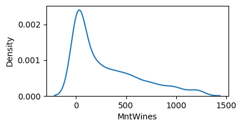

```
MntWines - 15.0%: Not Gaussian (reject H0)
MntWines - 10.0%: Not Gaussian (reject H0)
MntWines - 5.0%: Not Gaussian (reject H0)
MntWines - 2.5%: Not Gaussian (reject H0)
MntWines - 1.0%: Not Gaussian (reject H0)


 Column:  MntFruits  - Statistic: 214.894
```

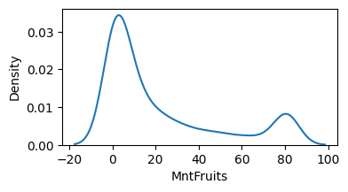

```
MntFruits - 15.0%: Not Gaussian (reject H0)
MntFruits - 10.0%: Not Gaussian (reject H0)
MntFruits - 5.0%: Not Gaussian (reject H0)
MntFruits - 2.5%: Not Gaussian (reject H0)
MntFruits - 1.0%: Not Gaussian (reject H0)


 Column:  MntMeatProducts  - Statistic: 194.064
```

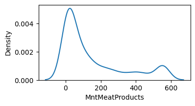

```
MntMeatProducts - 15.0%: Not Gaussian (reject H0)
MntMeatProducts - 10.0%: Not Gaussian (reject H0)
MntMeatProducts - 5.0%: Not Gaussian (reject H0)
MntMeatProducts - 2.5%: Not Gaussian (reject H0)
MntMeatProducts - 1.0%: Not Gaussian (reject H0)
```

```python
for column in ['MntWines',"MntFruits", "MntMeatProducts"]:
    result = stats.anderson(marketing_data_encoded[column], dist='norm')
    print('\n\n',f'Column: \033[1m {column} \033[0m - Statistic: {result.statistic:.3f}')
    plt.figure(figsize=(4,2))
    sns.kdeplot(marketing_data_encoded[column])
    plt.show()

    # Interpreting the result
    for i in range(len(result.critical_values)):
        sl, cv = result.significance_level[i], result.critical_values[i]
        if result.statistic < cv:
            print(f'{column} - {sl}%: Gaussian (fail to reject H0)')
        else:
            print(f'{column} - {sl}%: Not Gaussian (reject H0)')
```

For `'MntWines'`, `'MntFruits'`,`'MntMeatProducts'` the test statistic is higher that critical values at all significance levels. Hence, we reject the Null hypothesis that the feature is Normally distributed.

- These columns are **Not Normally Distributed**

Since all the numerical continuous features are not normally distributed, we need to tranform the data using variance stabilizing transformations to try and achieve normality. This is in order to be able to use T-test, Anova & Chi-square tests. If we fail to achieve normality after transformation, we will have to go for the Non-parametric tests for hypothesis.

```python
# Variance Stabilizing Transformations

from sklearn.preprocessing import PowerTransformer

transformer = PowerTransformer(method='yeo-johnson')
transformed_data_numpy = transformer.fit_transform(marketing_data_encoded)

marketing_data_transformed = pd.DataFrame(transformed_data_numpy, columns = marketing_data_encoded.columns)
```

```python
# Standardization

from sklearn.preprocessing import RobustScaler

scaler = RobustScaler()

# Fit and transform
marketing_data_scaled_np = scaler.fit_transform(marketing_data_transformed)
marketing_data_scaled = pd.DataFrame(marketing_data_scaled_np, columns = marketing_data_transformed.columns)
```

Robust scalar:

- makes median as 0
- less sensitive to outliers => hence ROBUST

```
 Column:  NumDealsPurchases  - Statistic: 119.338
```

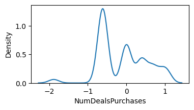

```
NumDealsPurchases - 15.0%: Not Gaussian (reject H0)
NumDealsPurchases - 10.0%: Not Gaussian (reject H0)
NumDealsPurchases - 5.0%: Not Gaussian (reject H0)
NumDealsPurchases - 2.5%: Not Gaussian (reject H0)
NumDealsPurchases - 1.0%: Not Gaussian (reject H0)


 Column:  NumWebPurchases  - Statistic: 25.919
```

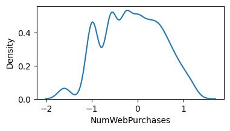

```
NumWebPurchases - 15.0%: Not Gaussian (reject H0)
NumWebPurchases - 10.0%: Not Gaussian (reject H0)
NumWebPurchases - 5.0%: Not Gaussian (reject H0)
NumWebPurchases - 2.5%: Not Gaussian (reject H0)
NumWebPurchases - 1.0%: Not Gaussian (reject H0)


 Column:  NumCatalogPurchases  - Statistic: 67.675
```

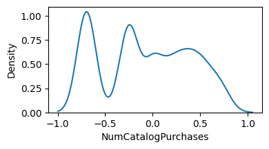

```
NumCatalogPurchases - 15.0%: Not Gaussian (reject H0)
NumCatalogPurchases - 10.0%: Not Gaussian (reject H0)
NumCatalogPurchases - 5.0%: Not Gaussian (reject H0)
NumCatalogPurchases - 2.5%: Not Gaussian (reject H0)
NumCatalogPurchases - 1.0%: Not Gaussian (reject H0)


 Column:  NumStorePurchases  - Statistic: 38.461
```

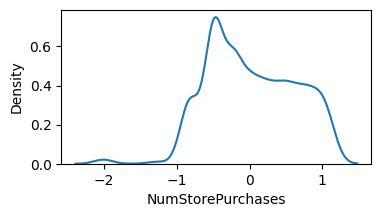

```
NumStorePurchases - 15.0%: Not Gaussian (reject H0)
NumStorePurchases - 10.0%: Not Gaussian (reject H0)
NumStorePurchases - 5.0%: Not Gaussian (reject H0)
NumStorePurchases - 2.5%: Not Gaussian (reject H0)
NumStorePurchases - 1.0%: Not Gaussian (reject H0)
```

```python
# Checking for Normality

for column in ['NumDealsPurchases','NumWebPurchases', 'NumCatalogPurchases','NumStorePurchases']:
    result = stats.anderson(marketing_data_scaled[column], dist='norm')
    print('\n\n',f'Column: \033[1m {column} \033[0m - Statistic: {result.statistic:.3f}')
    plt.figure(figsize=(4,2))
    sns.kdeplot(marketing_data_scaled[column])
    plt.show()

    # Interpreting the result
    for i in range(len(result.critical_values)):
        sl, cv = result.significance_level[i], result.critical_values[i]
        if result.statistic < cv:
            print(f'{column} - {sl}%: Gaussian (fail to reject H0)')
        else:
            print(f'{column} - {sl}%: Not Gaussian (reject H0)')
```

We see that transformation and scaling have failed to normalize the data. Hence, we will go for Non Parametric tests for Hypothesis testing.